# Prosper Loan Data Analysis

## by Akinyemi Tito

## Investigation Overview

```
In this analysis I wanted to look at the distribution of loan status and why most loans were listed
```

## Dataset Overview

```
The loan dataframe contains 21 columns of all rows that had a prosper rating. The columns include ProsperRating (alpha), LoanStatus, EmploymentStatus, IsBorrowerHomeowner, BorrowerAPR and many more.
```

## Distribution of Prosper Rating (Alpha)

Prosper Rating is assigned when a loan is listed. The column is plotted in a bar chart to show the count of each category.

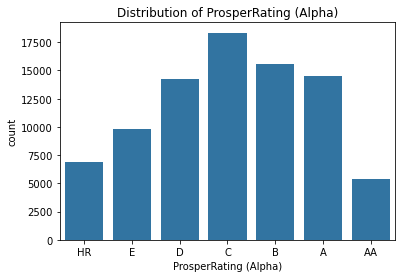

IsBorrowerHomeowner takes two values of true or false. Most borrowers own a home and are employed as the Employment status displays. This makes me wonder why they apply for a loan when they clearly have a source of income.

[figure not shown]

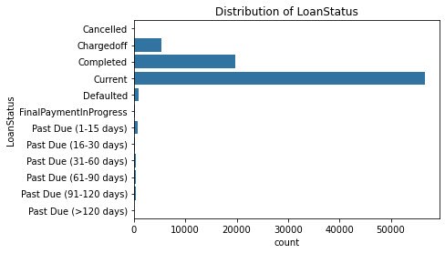

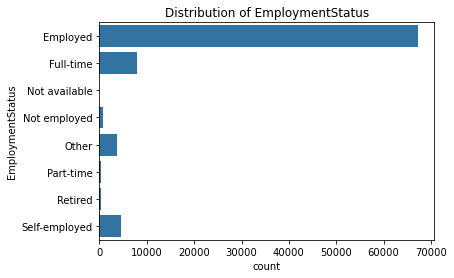

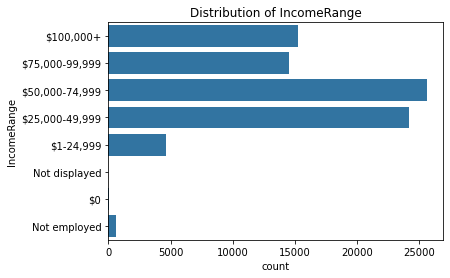

## Listing Category Distribution

> For each loan the borrower lists it under a category for why the loan is required.

Below is the key to each figure encoded: 0 - Not Available, 1 - Debt Consolidation, 2 - Home Improvement, 3 - Business, 4 - Personal Loan, 5 - Student Use, 6 - Auto, 7- Other, 8 - Baby&Adoption, 9 - Boat, 10 - Cosmetic Procedure, 11 - Engagement Ring, 12 - Green Loans, 13 - Household Expenses, 14 - Large Purchases, 15 - Medical/Dental, 16 - Motorcycle, 17 - RV, 18 - Taxes, 19 - Vacation, 20 - Wedding Loans

> Most loans are listed under Debt consolidation. Most of the loans are taken to pay off already acquired debt which is not a very smart decision.

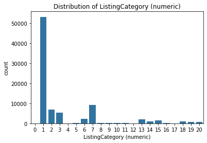

## Do people who earn more borrow higher amounts of money?

We would expect that people who earn more won't have to borrow high amounts of money but, this is not the case as earning prowess positively correlates with the amount borrowed. Although there are a few outliers, in general people tend to borrow lesser amounts when their income range is much lesser.

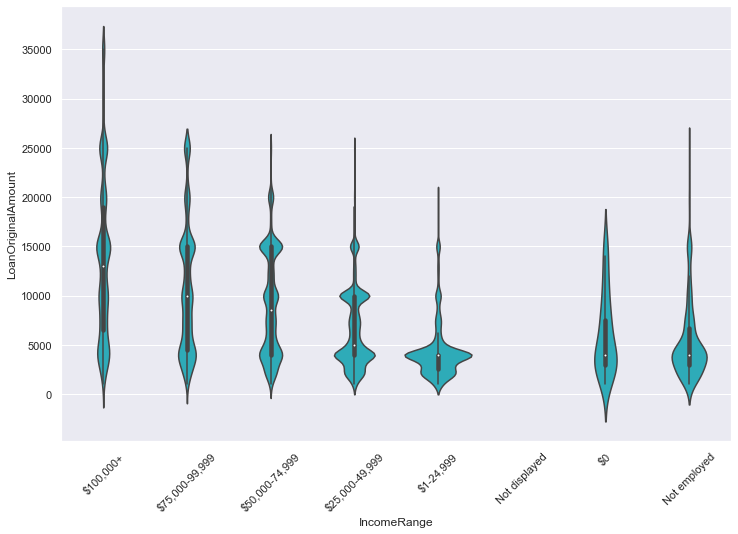

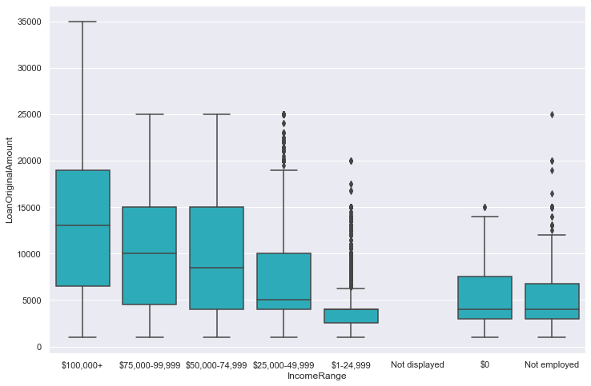